# Tipología y ciclo de vida de los datos

# Práctica 2: ¿Cómo realizar la limpieza y análisis de datos?

Autor: Jhon Jairo Realpe

Enero 2023

Se cargan las librerías necesarias para el estudio

```r
if(!require('dplyr')) install.packages('dplyr'); library('dplyr')
if(!require('tidyverse')) install.packages('tidyverse'); library('tidyverse')
if(!require('VIM')) install.packages('VIM'); library('VIM')
if(!require('DAAG')) install.packages('DAAG'); library('DAAG')
if(!require('Metrics')) install.packages('Metrics'); library('Metrics')
if(!require('pROC')) install.packages('pROC'); library('pROC')
if(!require('haven')) install.packages('haven'); library('haven')
if(!require('e1071')) install.packages('e1071'); library('e1071')
if(!require('psych')) install.packages('psych'); library('psych')
if(!require('reshape2')) install.packages('reshape2'); library('reshape2')
if(!require('inspectdf')) install.packages('inspectdf'); library('inspectdf')
if(!require('corrplot')) install.packages('corrplot'); library('corrplot')
if(!require('grid')) install.packages('grid'); library('grid')
if(!require('gridExtra')) install.packages('gridExtra'); library('gridExtra')
if(!require('car')) install.packages('car'); library('car')
if(!require('caret')) install.packages('caret'); library('caret')
if(!require('ipred')) install.packages('ipred'); library('ipred')
if(!require('sjPlot')) install.packages('sjPlot'); library('sjPlot')
if(!require('forecast')) install.packages('forecast'); library('forecast')
```

# 1 **Lectura del fichero**

Se carga el conjunto de datos

```r
data <- read_dta('data/gpa2.dta')
```

Se verifica la estructura y el tipo de datos

```r
str(data)
```

```
## tibble [4,137 × 12] (S3: tbl_df/tbl/data.frame)
##  $ sat     : num [1:4137] 920 1170 810 940 1180 980 880 980 1240 1230 ...
##   ..- attr(*, "label")= chr "combined SAT score"
##   ..- attr(*, "format.stata")= chr "%10.0g"
##  $ tothrs  : num [1:4137] 43 18 14 40 18 114 78 55 18 17 ...
##   ..- attr(*, "label")= chr "total hours through fall semest"
##   ..- attr(*, "format.stata")= chr "%10.0g"
##  $ colgpa  : num [1:4137] 2.04 4 1.78 2.42 2.61 ...
##   ..- attr(*, "label")= chr "GPA after fall semester"
##   ..- attr(*, "format.stata")= chr "%9.0g"
##  $ athlete : num [1:4137] 1 0 1 0 0 0 0 0 0 0 ...
##   ..- attr(*, "label")= chr "=1 if athlete"
##   ..- attr(*, "format.stata")= chr "%8.0g"
##  $ verbmath: num [1:4137] 0.484 0.828 0.884 0.808 0.735 ...
##   ..- attr(*, "label")= chr "verbal/math SAT score"
##   ..- attr(*, "format.stata")= chr "%9.0g"
##  $ hsize   : num [1:4137] 0.1 9.4 1.19 5.71 2.14 2.68 3.11 2.68 3.67 0.1 ...
##   ..- attr(*, "label")= chr "size grad. class, 100s"
##   ..- attr(*, "format.stata")= chr "%10.0g"
##  $ hsrank  : num [1:4137] 4 191 42 252 86 41 161 101 161 3 ...
##   ..- attr(*, "label")= chr "rank in grad. class"
##   ..- attr(*, "format.stata")= chr "%10.0g"
##  $ hsperc  : num [1:4137] 40 20.3 35.3 44.1 40.2 ...
##   ..- attr(*, "label")= chr "high school percentile, from top"
##   ..- attr(*, "format.stata")= chr "%9.0g"
##  $ female  : num [1:4137] 1 0 0 0 0 1 0 0 0 0 ...
##   ..- attr(*, "label")= chr "=1 if female"
##   ..- attr(*, "format.stata")= chr "%9.0g"
##  $ white   : num [1:4137] 0 1 1 1 1 1 0 1 1 1 ...
##   ..- attr(*, "label")= chr "=1 if white"
##   ..- attr(*, "format.stata")= chr "%9.0g"
##  $ black   : num [1:4137] 0 0 0 0 0 0 0 0 0 0 ...
##   ..- attr(*, "label")= chr "=1 if black"
##   ..- attr(*, "format.stata")= chr "%9.0g"
##  $ hsizesq : num [1:4137] 0.01 88.36 1.42 32.6 4.58 ...
##   ..- attr(*, "label")= chr "hsize^2"
##   ..- attr(*, "format.stata")= chr "%9.0g"
```

# 2 **Descripción del dataset**

El archivo contiene datos sobre el promedio de calificaciones (GPA) de los estudiantes matriculados en una universidad de Estados Unidos. El número de observaciones es igual a 4137 test asociados al Scholastic Assessment Test (SAT), que es el examen nacional estandarizado que realizan todos los estudiantes universitarios cada cuatro años.

También se aprecia que contiene 12 variables, todas de tipo numéricas. Sin embargo, se resalta que las variables athelete, female, white y black son de tipo categórico y las variables restantes son continuas.

| No | Variable | Descripción | Tipo |
| --- | --- | --- | --- |
| 1 | sat | Examen SAT combinado (lectura crítica/escritura) | Continua |
| 2 | tothrs | Total de horas cursadas de clase hasta terminar el semestre | Continua |
| 3 | colgpa | Promedio de notas al terminar el semestre | Continua |
| 4 | athlete | = 1 si es atleta | Categórica |
| 5 | verbmath | competencia verbal/competencia matemática del examen SAT | Continua |
| 6 | hsize | Tamaño del total de graduados en escuelas secundaria(en cientos) | Continua |
| 7 | hsrank | rango respecto al total de graduados | Continua |
| 8 | hsperc | Percentil del total de graduados respecto al total de estudiantes | Continua |
| 9 | female | = 1 si es mujer | Categórica |
| 10 | white | = 1 si es blanco | Categórica |
| 11 | black | = 1 si es negro | Categórica |
| 12 | hsizesq | Total de graduados en escuelas secundaria(al cuadrado) | Continua |

# 3 **Limpieza de los datos**

Se hace la conversión de los datos a valores numéricos y categóricos.

```r
data$sat <- as.numeric(data$sat)
data$tothrs <- as.numeric(data$tothrs)
data$colgpa <- as.numeric(data$colgpa)
data$verbmath <- as.numeric(data$verbmath)
data$hsize <- as.numeric(data$hsize)
data$hsrank <- as.numeric(data$hsrank)
data$hsperc <- as.numeric(data$hsperc)
data$hsizesq <- as.numeric(data$hsizesq)
data$athlete <- as.numeric(data$athlete)
data$female <- as.numeric(data$female)
data$white <- as.numeric(data$white)
data$black <- as.numeric(data$black)

data$athlete <- ifelse(data$athlete==1, TRUE, FALSE)
data$female <- ifelse(data$female==1, TRUE, FALSE)
data$white <- ifelse(data$white==1, TRUE, FALSE)
data$black <- ifelse(data$black==1, TRUE, FALSE)

data$athlete <- as.factor(data$athlete)
data$female <- as.factor(data$female)
data$white <- as.factor(data$white)
data$black <- as.factor(data$black)
```

Se hace separación de los atributos en numéricos continuos y categóricos, para posteriores análisis

```r
data_num <- select_if(data, is.numeric)
data_cat <- select_if(data, is.factor)
```

## 3.1 **Gestión elementos nulos o vacíos**

Se verifica que el conjunto de datos no tiene valores nulos.

```r
colSums(is.na(data))
```

```
##      sat   tothrs   colgpa  athlete verbmath    hsize   hsrank   hsperc
##        0        0        0        0        0        0        0        0
##   female    white    black  hsizesq
##        0        0        0        0
```

Se verifica que el conjunto de datos no tiene valores vacíos.

```r
colSums(data=='')
```

```
##      sat   tothrs   colgpa  athlete verbmath    hsize   hsrank   hsperc
##        0        0        0        0        0        0        0        0
##   female    white    black  hsizesq
##        0        0        0        0
```

**Observaciones**

Dado que el conjunto de datos no presenta ni valores nulos ni vacíos, no se aplica ninguna técnica correctiva.

## 3.2 **Identificación y gestión de valores extremos**

Para cada atributo continuo se grafica un histograma y un diagrama de bigotes para identificar valores extremos.

```r
graph_outliers <- function(data1, data2, name1, name2){

  nf = layout(
    rbind(
      c(1, 2),
      c(3, 4)
    )
  )


  boxplot(data1, main = name1)
  hist(data1, main=paste(c("Histogram", name1), collapse=" "), xlab="", col="blue")

  boxplot(data2, main = name2)
  hist(data2, main=paste(c("Histogram", name2), collapse=" "), xlab="", col="blue")
}
```

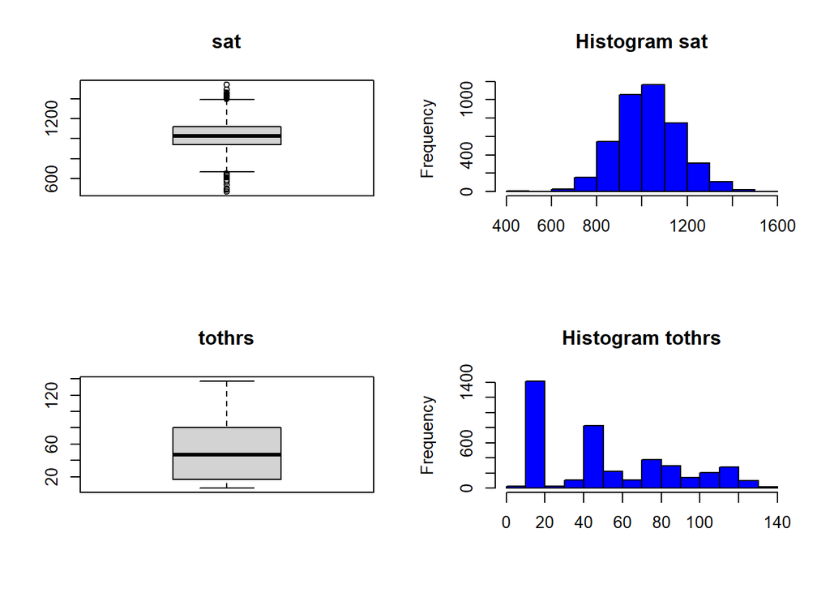

```r
graph_outliers(data_num$sat, data_num$tothrs, "sat", "tothrs")
```

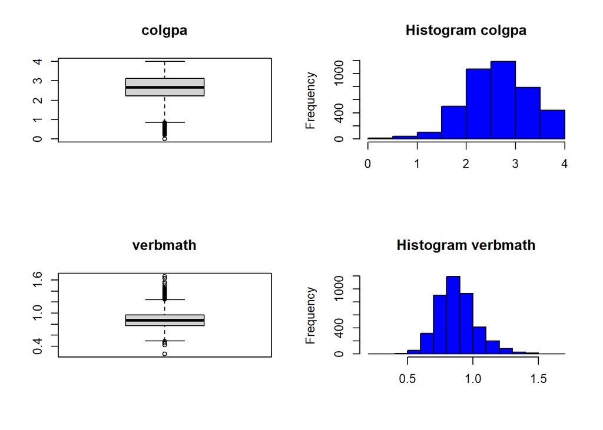

```r
graph_outliers(data_num$colgpa, data_num$verbmath, "colgpa", "verbmath")
```

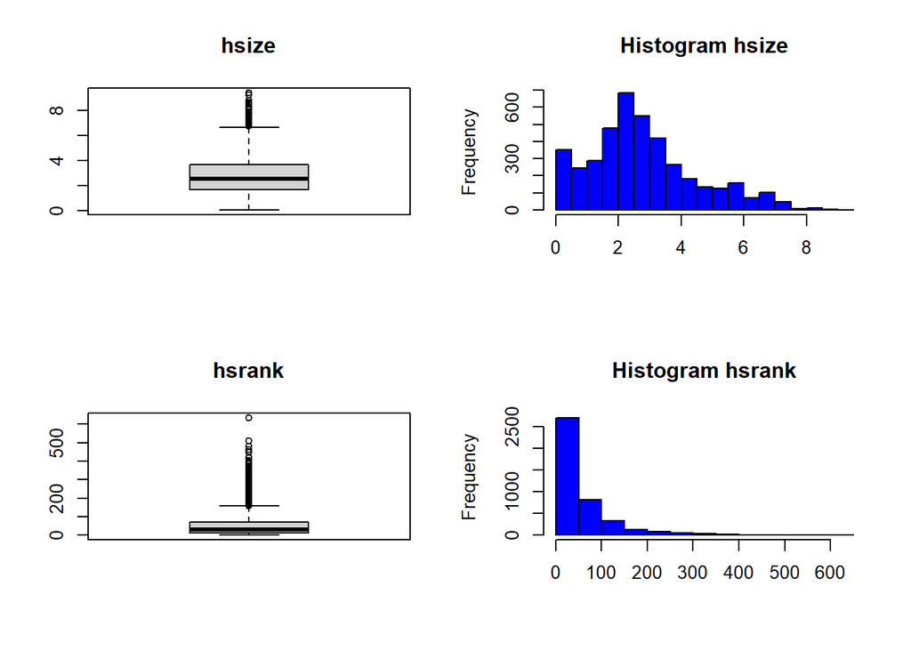

```r
graph_outliers(data_num$hsize, data_num$hsrank, "hsize", "hsrank")
```

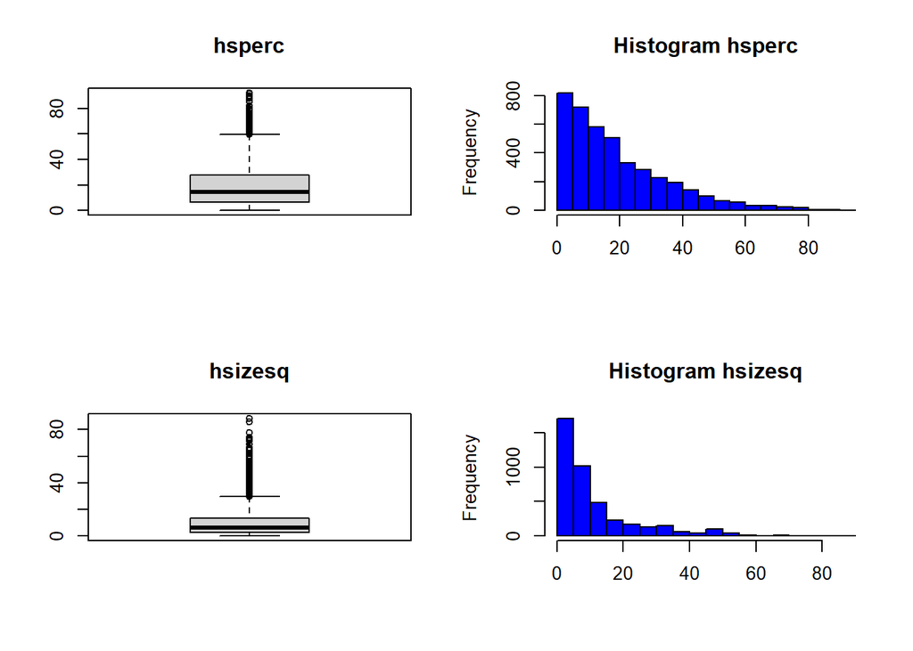

```r
graph_outliers(data_num$hsperc, data_num$hsizesq, "hsperc", "hsizesq")
```

Con la función stats integrada en boxplot, se extraen el número de valores extremos, es decir, todo valor que está fuera de los bigotes, que son las líneas que se ubica en el tercer cuartil +1.5 veces el rango intercuartílico y el primer cuartil -1.5 veces el rango intercuartílico.

A continuación se hace un resumen de los valores extremos en las variables numéricas.

```r
# Se extraen los valores atípicos
out_sat <- boxplot.stats(data_num$sat)$out
out_tothrs <- boxplot.stats(data_num$tothrs)$out
out_colgpa <- boxplot.stats(data_num$colgpa)$out
out_verbmath <- boxplot.stats(data_num$verbmath)$out
out_hsize <- boxplot.stats(data_num$hsize)$out
out_hsrank <- boxplot.stats(data_num$hsrank)$out
out_hsperc <- boxplot.stats(data_num$hsperc)$out
out_hsizesq <- boxplot.stats(data_num$hsizesq)$out

total_outliers <- c(length(out_sat), length(out_tothrs),
                    length(out_colgpa), length(out_verbmath),
                    length(out_hsize), length(out_hsrank),
                    length(out_hsperc), length(out_hsizesq))

# Se crea dataframe con la suma total de valores atípicos
names_rows <- data.frame(names(data_num))
total_outliers <- data.frame(rows.names=names(data_num), total_outliers)
total_outliers[order(total_outliers$total_outliers, decreasing=TRUE), ]
```

```
##   rows.names total_outliers
## 8    hsizesq            415
## 6     hsrank            267
## 5      hsize            169
## 7     hsperc            135
## 4   verbmath             82
## 1        sat             39
## 3     colgpa             34
## 2     tothrs              0
```

**Observaciones**

Con en esta información, a continuación se exponen los criterios para conservar o eliminar los valores extremos.

En primer lugar, las observaciones de la variable **hsizesq**, presentan un elevado número de valores extremos, esto se debe a que dicha variable es el valor cuadrado de la variable **hsize**, y por tanto los valores se hacen mas grandes y la distribución se sesga hacia la derecha. Dado que esta transformación no mejora las propiedades estadísticas de **hsize**, no se toma ninguna acción respecto a los valores extremos y se prescindirá de ella, en la sección de resolución de problemas y el análisis de modelos predictivos.

Respecto a la variable **hsrank** un 6.4% de los datos son valores extremos, para la variable **hsize** un 4.1% y para la variable **hsperc** 3.2%. Aunque la proporción es considerable y hace que las distribuciones tengan un elevado sesgo a la derecha, no se tiene información adicional del proceso de muestreo del experimento realizado. Por tal razón, no se tiene evidencia para descartar los valores y se decide no tomar ninguna acción correctiva.

Con el propósito de abordar el problema del sesgo en las distribuciones, en la sección 5 del presente documento, se procederá a aplicar la transformación mas adecuada, de modo que las variables tiendan a una distribución normal.

Respecto a la variable **verbmath**, los valores se obtienen de la división entre el examen de competencia verbal SAT, cuyo rango es de 200-800 y el examen de competencia matemática SAT, cuyo rango es de 200-800, tal como se reporta en:

https://www.theclassroom.com/verbal-sat-scores-8525646.html

https://blog.prepscholar.com/sat-score-range

Respecto a las variables **colgpa** y **sat**, en primer lugar se corrobora que los rangos sean coherentes en relación a los estándares definidos para estas variables. En este sentido los valores de **colgpa** están en el rango de 0-4 y para **sat** de 400-1600, tal como se reporta en:

https://satsuite.collegeboard.org/media/pdf/understanding-sat-scores.pdf

https://blog.prepscholar.com/sat-gpa-conversion-table

https://www.prepscholar.com/sat/s/colleges/Coe-College-SAT-scores-GPA

Respecto a la variable **tothrs** no realiza ninguna acción ya que no presenta valores extremos

# 4 **Análisis de los datos**

En esta sección se realiza el análisis de los datos, el cual se dividirá en dos apartados. En el primero se desarrolla el análisis de las variables numéricas y en el segundo el análisis de las variables categóricas.

## 4.1 **Análisis variables numéricas**

En primer lugar se realiza un análisis descriptivo de las variables numéricas, donde se presentan medidas de tendencia central.

### 4.1.1 **Análisis Descriptivo**

```r
# Se hace un resumen de las variables numéricas y categóricas
summary(data_num)
```

```
##       sat           tothrs           colgpa         verbmath
##  Min.   : 470   Min.   :  6.00   Min.   :0.000   Min.   :0.2597
##  1st Qu.: 940   1st Qu.: 17.00   1st Qu.:2.210   1st Qu.:0.7759
##  Median :1030   Median : 47.00   Median :2.660   Median :0.8667
##  Mean   :1030   Mean   : 52.83   Mean   :2.653   Mean   :0.8805
##  3rd Qu.:1120   3rd Qu.: 80.00   3rd Qu.:3.120   3rd Qu.:0.9649
##  Max.   :1540   Max.   :137.00   Max.   :4.000   Max.   :1.6667
##      hsize          hsrank           hsperc           hsizesq
##  Min.   :0.03   Min.   :  1.00   Min.   : 0.1667   Min.   : 0.0009
##  1st Qu.:1.65   1st Qu.: 11.00   1st Qu.: 6.4328   1st Qu.: 2.7225
##  Median :2.51   Median : 30.00   Median :14.5833   Median : 6.3001
##  Mean   :2.80   Mean   : 52.83   Mean   :19.2371   Mean   :10.8535
##  3rd Qu.:3.68   3rd Qu.: 70.00   3rd Qu.:27.7108   3rd Qu.:13.5424
##  Max.   :9.40   Max.   :634.00   Max.   :92.0000   Max.   :88.3600
```

Para complementar el análisis, se aplican otros estadísticos denominados robustos, ya que no se ven influenciados por valores extremos.

```r
mean_num <- sapply(data_num, mean, na.rm=TRUE)
median_num <- sapply(data_num, median, na.rm=TRUE)
var_num <- sapply(data_num, var, na.rm=TRUE)
sd_num <- sapply(data_num, sd, na.rm=TRUE)
skewness_num <- sapply(data_num, skewness, na.rm=TRUE)
kurtosis_num <- sapply(data_num, kurtosis, na.rm=TRUE)
w_mean_num <- sapply(data_num, winsor.mean, na.rm=TRUE)
kurtosis_num <- sapply(data_num, kurtosis, na.rm=TRUE)

fmean_trim <- function(x, trim) mean(x, trim=trim)
mean_trim <- sapply(data_num, fmean_trim, trim=0.05)

fmean_win <- function(x, trim) winsor.mean(x, trim=trim)
mean_win <- sapply(data_num, fmean_win, trim=0.05)

IQR_num <- sapply(data_num, IQR, na.rm=TRUE)
mad_num <- sapply(data_num, mad, na.rm=TRUE)

stats <- rbind(mean_num, median_num, var_num, sd_num,
               skewness_num, kurtosis_num, mean_trim,
               mean_win, IQR_num, mad_num)

stats <- data.frame(stats)

stats
```

```
##                       sat       tothrs     colgpa   verbmath     hsize
## mean_num     1.030331e+03   52.8322456  2.6526855 0.88053690 2.7997269
## median_num   1.030000e+03   47.0000000  2.6600001 0.86667001 2.5100000
## var_num      1.943275e+04 1248.1802656  0.4337997 0.02223763 3.0157075
## sd_num       1.394014e+02   35.3295948  0.6586347 0.14912286 1.7365793
## skewness_num 7.330814e-02    0.4962826 -0.2145894 0.64960778 0.7526996
## kurtosis_num 1.839500e-01   -1.0002385  0.1107034 1.06721577 0.2675631
## mean_trim    1.029479e+03   51.2706040  2.6632081 0.87496830 2.7117906
## mean_win     1.030527e+03   52.6379019  2.6653783 0.87836610 2.7707701
## IQR_num      1.800000e+02   63.0000000  0.9099998 0.18904996 2.0300000
## mad_num      1.334340e+02   45.9606000  0.6671701 0.14065422 1.4232960
##                   hsrank     hsperc    hsizesq
## mean_num       52.830070  19.237070  10.853449
## median_num     30.000000  14.583333   6.300100
## var_num      4183.966039 274.522721 159.341495
## sd_num         64.683584  16.568727  12.623054
## skewness_num    2.571851   1.291362   1.981690
## kurtosis_num    9.137948   1.528582   4.099193
## mean_trim      43.993826  17.733576   9.277801
## mean_win       48.784482  18.638553  10.358933
## IQR_num        59.000000  21.278096  10.819900
## mad_num        35.582400  14.045921   6.638490
```

**Observaciones**

Para las variables **sat**, **colgpa** y **verbmath**, los valores de la media normal y la media winsorizada y media trim, son similares, lo cual es coherente dado que dichas variables tienen una distribución normal.

Respecto a la variable **tothrs** los valores de la media normal y la media winsorizada y media trim son similares, lo cual tiene sentido, dado que sus valores tienden ha una distribución uniforme.

Para complementar el análisis anterior, a continuación se grafica los histograma de las 8 variables numéricas.

Se observa un aspecto interesante en la variable **tothrs**, su distribución no es precisamente una distribución uniforme sino una distribución multimodal.

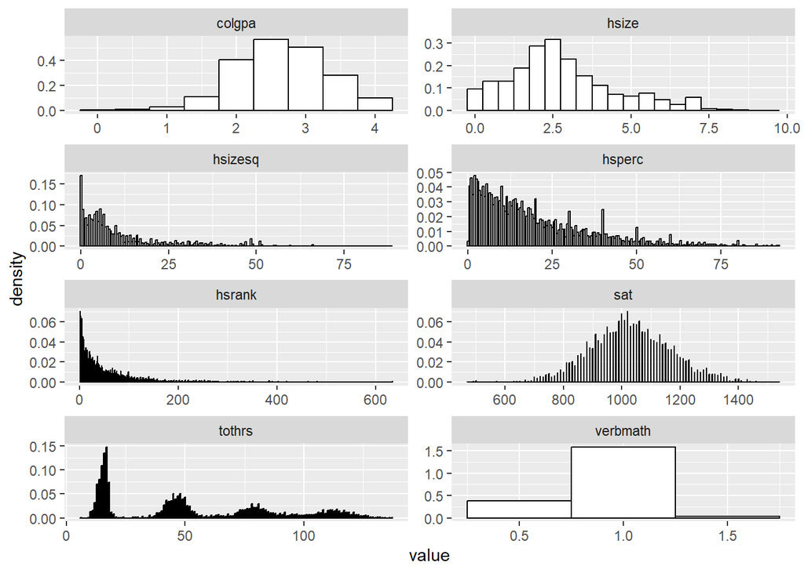

```r
ggplot(gather(data_num, cols, value), aes(x = value)) +
  geom_histogram(aes(y = after_stat(density)),
                 binwidth = 0.5,
                 colour = "black",
                 fill = "white") +
  facet_wrap(.~cols, ncol = 2, scales = 'free')
```

Continuando con el análisis en este sección se plantea un análisis multivariable, para ello se realiza un gráfico de dispersión.

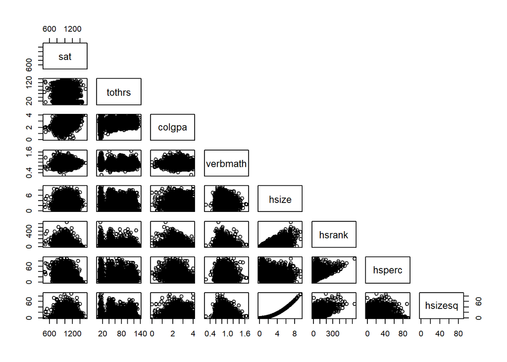

```r
pairs(data_num, upper.panel=NULL)
```

**Observaciones**

### 4.1.2 **Test de normalidad**

A continuación se realizan test de normalidad, basados en el análisis de histogramas y gráficos Q-Q

```r
graph_norm <- function(data1, data2, data3, data4, name1, name2, name3, name4){

  nf = layout(
    rbind(
      c(1, 2),
      c(3, 4)
    )
  )
qqnorm(data1, main=paste("Q-Q", name1)); qqline(data1)
qqnorm(data2, main=paste("Q-Q", name2)); qqline(data2)
qqnorm(data3, main=paste("Q-Q", name3)); qqline(data3)
qqnorm(data4, main=paste("Q-Q", name4)); qqline(data4)

}
```

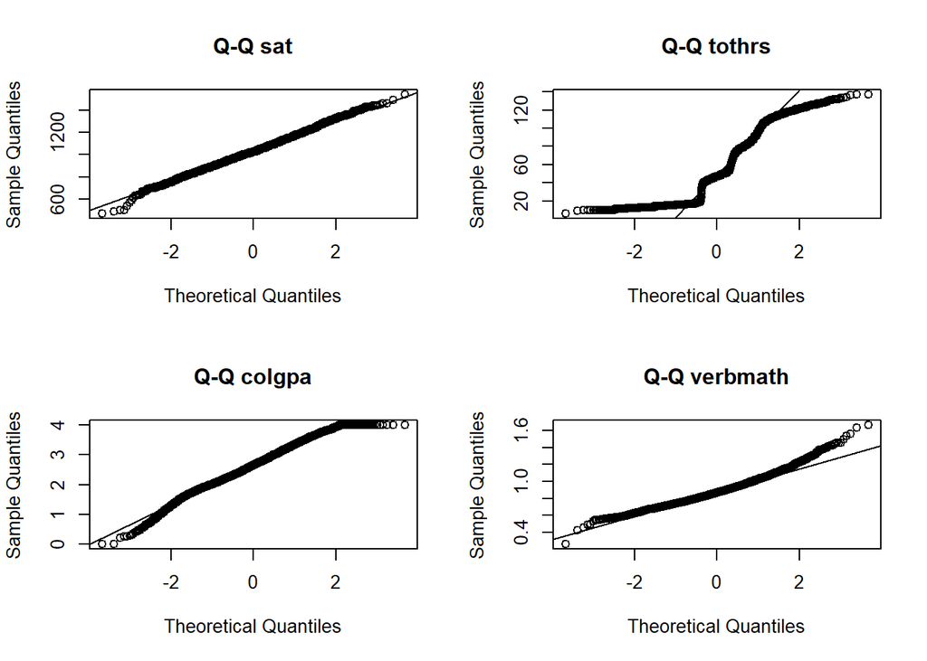

```r
graph_norm(data_num$sat,
           data_num$tothrs,
           data_num$colgpa,
           data_num$verbmath,
           "sat",
           "tothrs",
           "colgpa",
           "verbmath")
```

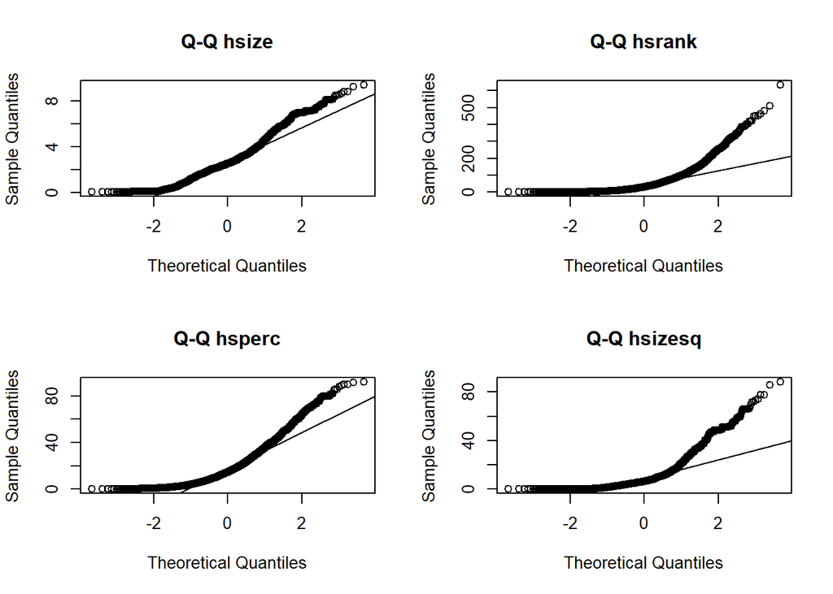

```r
graph_norm(data_num$hsize,
           data_num$hsrank,
           data_num$hsperc,
           data_num$hsizesq,
           "hsize",
           "hsrank",
           "hsperc",
           "hsizesq")
```

**Observaciones**

Del análisis del histograma y gráfico Q-Q se concluye lo siguiente:

- **sat**: sigue una distribución normal.
- **tothrs**: no sigue una distribución normal. Presenta múltiple modas.
- **colgpa**: sigue una distribución normal.
- **verbmath** sigue una distribución normal.
- **hize**: no normal, tiene sesgo a la derecha.
- **hsrank**: no normal, tiene sesgo a la derecha.
- **hsperc**: no normal, tiene sesgo a la derecha.
- **hisisq**: no normal, tiene sesgo a la derecha.

A continuación se aplican los test de Kolmogorov-Smirnov y Shapiro-Wilk, para evaluar la normalidad de las variables, desde un enfoque cuantitativo.

```r
ks_test <- function(x) ks.test(x, pnorm, mean(x), sd(x))$p.value
norm_test <- sapply(data_num, ks_test)
norm_test
```

```
##          sat       tothrs       colgpa     verbmath        hsize       hsrank
## 3.927987e-04 0.000000e+00 6.397961e-02 8.142436e-08 0.000000e+00 0.000000e+00
##       hsperc      hsizesq
## 0.000000e+00 0.000000e+00
```

```r
sp_test <- function(x) shapiro.test(x)$p.value
norm_test <- sapply(data_num, sp_test)
norm_test
```

```
##          sat       tothrs       colgpa     verbmath        hsize       hsrank
## 4.415310e-05 1.790721e-46 1.847936e-15 6.068512e-25 1.467518e-34 2.283282e-63
##       hsperc      hsizesq
## 1.561515e-48 8.431454e-61
```

**Observaciones**

No obstante, y tras considerar el análisis gráfico y considerando el teorema de límite central (el tamaño de la muestra para cada variables es de 4137 observaciones), se puede afirmar que al menos las variables **sat**, **verbmath** y **colgpa**, tienen una distribución normal.

### 4.1.3 **Análisis de correlación**

Dado que la mayoría de las variables no siguen una distribución normal, se aplicará la técnica de correlación de spearman, en la cual no asume ninguna suposición sobre la distribución de los datos.

```r
tab_corr(
  data_num,
  na.deletion = "pairwise",
  corr.method = "spearman",
  p.numeric = FALSE,
  show.p = TRUE,
  use.viewer = FALSE,
  triangle = 'lower')
```

|  | sat | tothrs | colgpa | verbmath | hsize | hsrank | hsperc | hsizesq |
| --- | --- | --- | --- | --- | --- | --- | --- | --- |
| sat |  |  |  |  |  |  |  |  |
| tothrs | 0.030 |  |  |  |  |  |  |  |
| colgpa | 0.395*** | 0.144*** |  |  |  |  |  |  |
| verbmath | -0.004 | 0.004 | 0.016 |  |  |  |  |  |
| hsize | 0.081*** | -0.046** | -0.004 | -0.050** |  |  |  |  |
| hsrank | -0.234*** | -0.119*** | -0.393*** | -0.031* | 0.593*** |  |  |  |
| hsperc | -0.325*** | -0.127*** | -0.483*** | -0.001 | -0.024 | 0.713*** |  |  |
| hsizesq | 0.081*** | -0.046** | -0.004 | -0.050** | 1.000*** | 0.593*** | -0.024 |  |
| Computed correlation used spearman-method with pairwise-deletion. |  |  |  |  |  |  |  |  |

**Observaciones**

Los valores en negrita sugieren que el p-value es significativo y en caso contrario que no es significativo. De acuerdo a lo anterior, se puede afirmar por ejemplo que la correlación usando el método de spearman para las variables **colgpa** y **sat** es de 0.395 con un nivel de confianza del 95%. Por el contrario, no se puede concluir que exista correlación entre **verbmath** y **colgpa**, dado que el p-value es mayor que 0.05.

A continuación, se crea gráfico de correlación, para visualizar de forma mas clara los resultados obtenidos.

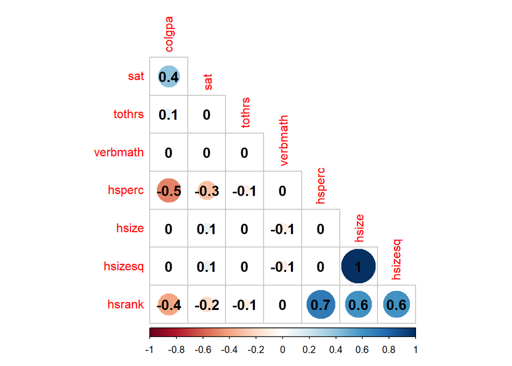

```r
corr <- round(cor( data_num, method = 'spearman' ), 1)

corrplot(cor = corr,
         method = "circle",
         type = "lower",
         order = "FPC",
         addCoef.col = "black",
         diag = FALSE,
         number.cex=1.2,
         tl.cex = 1.0)
```

Del gráfico y de los resultados de la sección anterior, se concluye que hay correlación positiva entre **hsrank** y **hsperc**, **hsize**. y negativa entre **hsrank**, **hsperc** y **colgpa** y **sat**, con un nivel de confianza del 95%.

### 4.1.4 **Análisis de linealidad entre variables colgpa y sat en función de las variables continuas**

Dado que el interés es buscar relaciones que expliquen los valores obtenidos para colgpa y sat, a continuación se hace un análisis de dichas variables, en función de las variables continuas restantes.

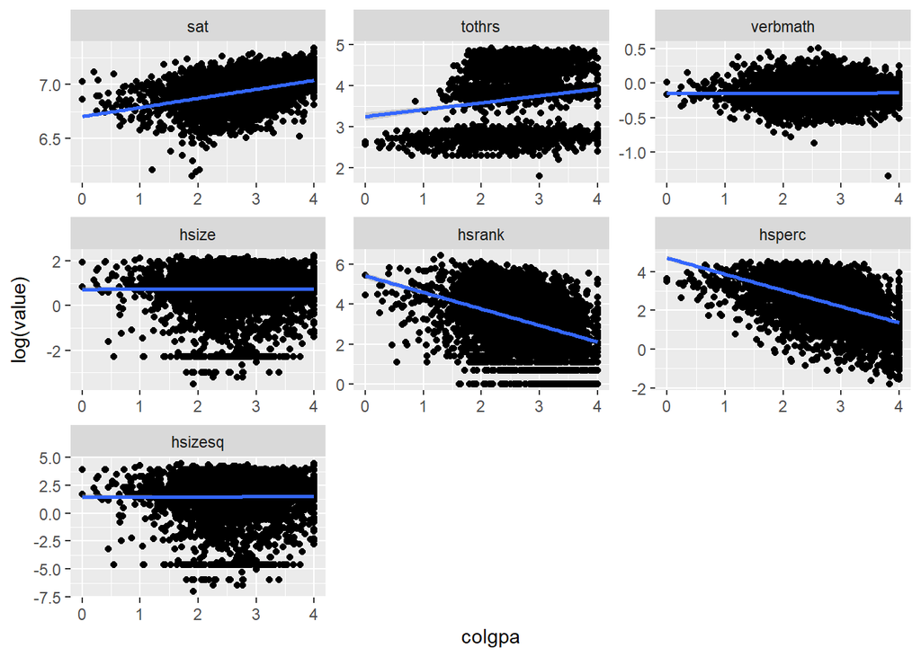

```r
data_colgpa_melt <- melt(data_num, id.vars="colgpa")

ggplot(data_colgpa_melt, aes(colgpa, log(value))) +
  geom_point() +
  geom_smooth(method = "lm") +
  facet_wrap(~variable, scales = "free", ncol = 3)
```

### 4.1.5 **Análisis de linealidad entre variables continuas y sat**

Al igual que la sección anterior se hace un análisis de linealidad entre la variable **sat** y el resto de variables continuas.

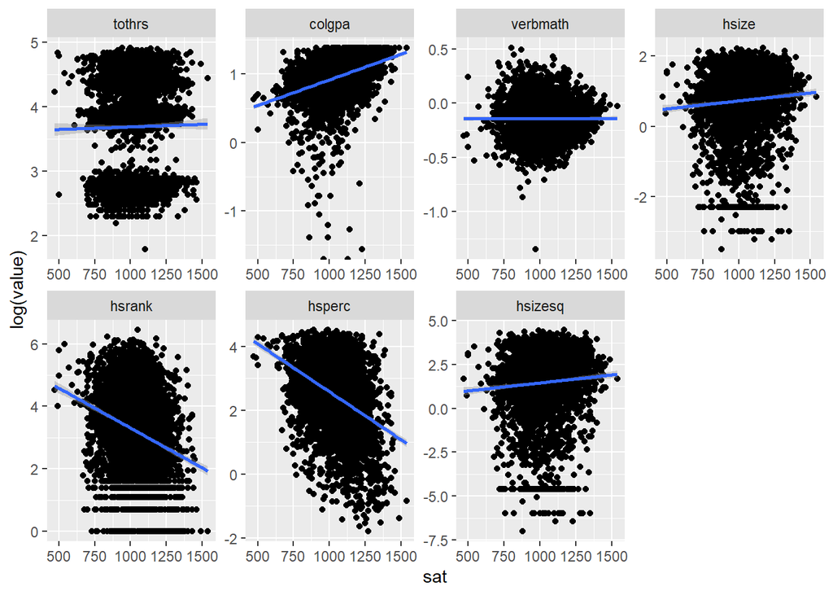

```r
data_sat_melt <- melt(data_num, id.vars="sat")

ggplot(data_sat_melt, aes(sat,log(value))) +
  geom_point() +
  geom_smooth(method = "lm") +
  facet_wrap(~variable, scales = "free", ncol = 4)
```

**Observaciones**

## 4.2 **Análisis variables Categóricas**

En esta sección se realiza el análisis de las variables categóricas.

### 4.2.1 **Análisis Descriptivo**

```r
summary(data_cat)
```

```
##   athlete       female       white        black
##  FALSE:3943   FALSE:2277   FALSE: 308   FALSE:3908
##  TRUE : 194   TRUE :1860   TRUE :3829   TRUE : 229
```

```r
info_cat <- data_cat %>%
  inspect_cat()
info_cat
```

```
## # A tibble: 4 × 5
##   col_name   cnt common common_pcnt levels
##   <chr>    <int> <chr>        <dbl> <named list>
## 1 athlete      2 FALSE         95.3 <tibble [2 × 3]>
## 2 black        2 FALSE         94.5 <tibble [2 × 3]>
## 3 female       2 FALSE         55.0 <tibble [2 × 3]>
## 4 white        2 TRUE          92.6 <tibble [2 × 3]>
```

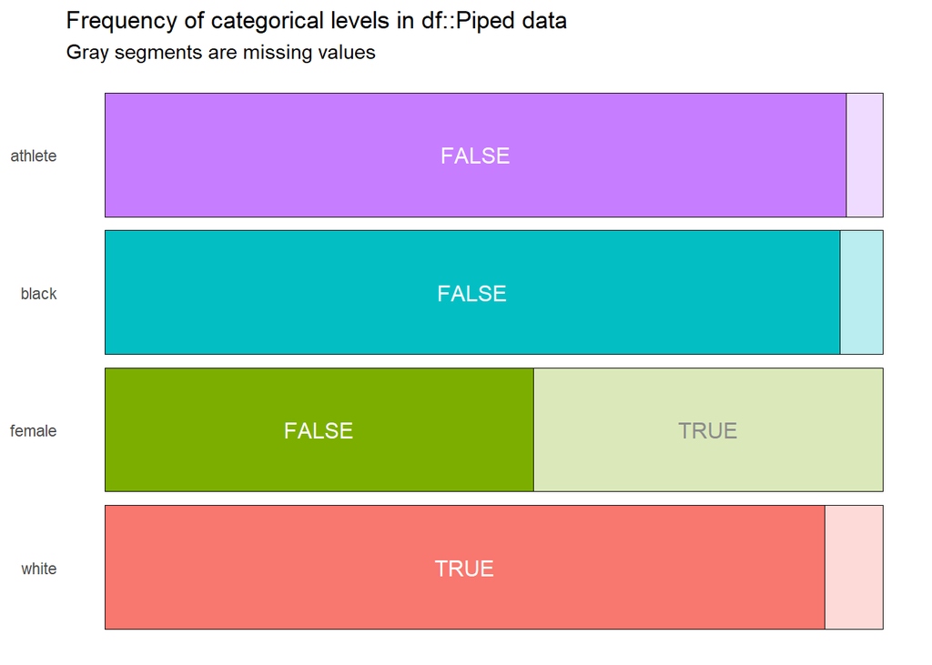

```r
info_cat %>%
  show_plot()
```

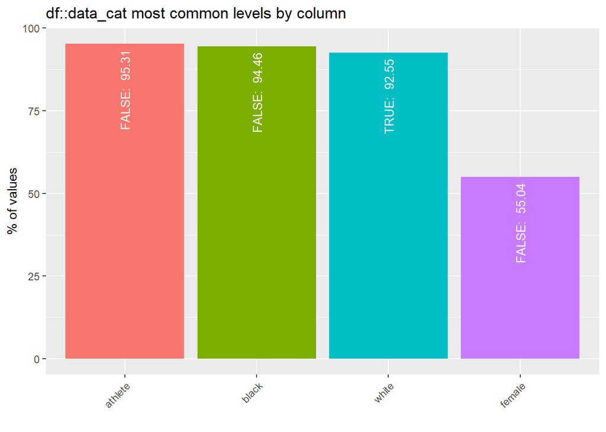

```r
inspect_imb(data_cat) %>%
  show_plot()
```

**Observaciones**

En la variable **athlete** se observa que el 95% de los datos están categorizados como falso, lo que indica un porcentaje alto de estudiantes que no son atletas. Respecto a la variable **black** se observa que un 94% de los datos están categorizados como falso, lo que indica que hay alto porcentaje de estudiantes de raza blanca. Respecto a la variable **White**, se observa que un 93% de los datos están cateogorizados como verdadero, lo que indica que hay un bajo porcentaje de estudiantes de raza negra. Finalmente para la variables **female**, se aprecia un 55% de los datos están categorizados como falso, lo que indica que el 55% de los estudiantes son hombres.

# 5 **Resolución del problema**

En este apartado se proponen dos problemas que se estudiarán desde dos enfoques, el primero desde la inferencia estadística y el segundo desde la perspectivas de modelos predictivos supervisados.

## 5.1 **Ser atleta influye en el promedio de la nota final (colgpa)**

En primera instancia se plantea el problema de determinar si el hecho de que un estudiante sea atleta influye en el promedio de la nota final.

El primer paso es seleccionar las variables de interés, para ello se selecciona la variable **colgpa** y se selecciona si el estudiante es o no atleta

```r
colgpa_athlete <- data$colgpa[data$athlete == TRUE]
colgpa_no_athlete <- data$colgpa[data$athlete == FALSE]
```

Se grafica el histograma sobre el que se superpone el valor medio y también un gráfico Q-Q para evaluar visualmente si las muestras de las dos variables de interés siguen una distribución normal.

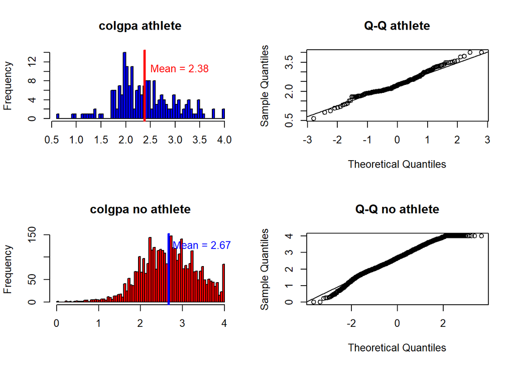

```r
nf = layout(
  rbind(
    c(1, 2),
    c(3, 4)
  )
)


hist(colgpa_athlete, breaks=100, main="colgpa athlete", xlab="", col="blue")
abline(v=mean(colgpa_athlete),
       col="red",
       lwd=3)
text(x=mean(colgpa_athlete)*1.3,
     y=mean(colgpa_athlete)*4.5,
     paste("Mean =", round(mean(colgpa_athlete),2)),
     col="red",
     cex=1)

qqnorm(colgpa_athlete, main="Q-Q athlete"); qqline(colgpa_athlete)

hist(colgpa_no_athlete, breaks=100, main="colgpa no athlete", xlab="", col="red")
abline(v=mean(colgpa_no_athlete),
       col="blue",
       lwd=3)
text(x=mean(colgpa_no_athlete)*1.3,
     y=mean(colgpa_no_athlete)*48,
     paste("Mean =", round(mean(colgpa_no_athlete),2)),
     col="blue",
     cex=1)

qqnorm(colgpa_no_athlete, main="Q-Q no athlete"); qqline(colgpa_no_athlete)
```

**Observaciones**

A partir de los gráficos Q-Q se aprecia que las dos muestras siguen una distribución normal, también se aprecia que el histograma tiene la forma de una distribución normal. Otro aspecto interesante es que el valor promedio para la muestra **colgpa no athlete**, es mayor respecto a **colgpa no athlete**. Preliminarmente a partir de este análisis descriptivo se puede inferir que el valor promedio de la nota en los estudiantes es diferente si este es o no atleta.

### 5.1.1 **Análisis de normalidad de las muestras**

Se realizan dos test estadísticos para evaluar la normalidad en las muestras.

```r
shapiro.test(colgpa_athlete)$p.value
```

```
## [1] 0.01152538
```

```r
ks.test(colgpa_athlete, pnorm, mean(colgpa_athlete), sd(colgpa_athlete))$p.value
```

```
## [1] 0.2334002
```

```r
shapiro.test(colgpa_no_athlete)$p.value
```

```
## [1] 1.725546e-15
```

```r
ks.test(colgpa_no_athlete, pnorm, mean(colgpa_no_athlete), sd(colgpa_no_athlete))$p.value
```

```
## [1] 0.05364117
```

**Observaciones**

Para la muestra **colgpa athlete** se aprecia que los dos test son contradictorios. Por un lado con el test shapiro-Wilk se concluye que la muestra no sigue una distribución normal y por otro lado, con el test de kolmogorov-Smirnov se concluye que si, lo mismo ocurre con la muestra **colgpa no athlete**

No obstante, teniendo en cuenta el análisis gráfico y considerando el teorema de límite central, se puede considerar que las dos muestras siguen una distribución normal.

### 5.1.2 **Análisis de la varianza entre las muestras**

Tras realizar el test de varianza se aprecia que el p-value es mayor que 0.05, con lo cual se infiere que las dos muestras tiene varianzas iguales.

```r
var_test <- var.test(colgpa_athlete, colgpa_no_athlete)
var_test$p.value
```

```
## [1] 0.07653321
```

### 5.1.3 **Pregunta de Investigación**

Para abordar el problema de forma específica, se plantea la siguiente pregunta:

¿Hay diferencias en el promedio de nota final de los estudiantes si son o no atletas?

### 5.1.4 **Hipótesis nula y alternativa**

Dado que es un problema de inferencia estadística, se deben plantear la hipótesis nula y alternativa. La hipótesis nula plantea que no hay diferencia en el promedio de nota final por el hecho que un estudiante sea atleta y la hipótesis alternativa plantea que si hay diferencia en el promedio de nota final.

$$H_{0}: u_{1} = u_{2} \\
H_{1}: u_{1} \neq u_{2}$$

### 5.1.5 **Justificación del test a aplicar**

El test a aplicar es el **contraste de dos muestras independientes sobre la media con varianzas desconocidas pero iguales**. A continuación se plantean la justificación de porque se considera adecuado dicho test para resolver el problema.

- El tamaño de las muestras es diferente y no tienen datos faltantes/nulos, por ende se considera que las dos muestras son independientes.

```r
length(colgpa_athlete)
```

```
## [1] 194
```

```r
length(colgpa_no_athlete)
```

```
## [1] 3943
```

- Se asume que las dos muestras siguen una distribución normal, de acuerdo al análisis gráfico y de acuerdo al teorema de limite central (tamaño de cada muestra mayor a 30).
- Las varianzas son iguales, lo cual se comprobó con el test de varianza
- Se desconoce la varianza poblacional.

### 5.1.6 **Cálculo**

```r
t.test(colgpa_athlete, colgpa_no_athlete, var.equal=TRUE)
```

```
##
##  Two Sample t-test
##
## data:  colgpa_athlete and colgpa_no_athlete
## t = -5.8983, df = 4135, p-value = 3.966e-09
## alternative hypothesis: true difference in means is not equal to 0
## 95 percent confidence interval:
##  -0.3791097 -0.1899574
## sample estimates:
## mean of x mean of y
##  2.381495  2.666028
```

### 5.1.7 **Interpretación**

De acuerdo al test anterior, se concluye que si hay diferencias en las notas de los estudiantes si estos son o no atletas, con un nivel de confianza del 95%. Lo anterior se infiere a partir del p-value, cuyo valor es menor que 0.05. De igual manera, el tobs esta fuera de la región de aceptación, con lo cual se rechaza la hipótesis nula.

## 5.2 **¿Se puede predecir la nota promedio final de los estudiantes?**

El problema de este apartado se abordará desde la perspectiva de modelos supervisados, en particular regresión lineal y árboles de decisión con técnica de ensamble.

### 5.2.1 **Modelo de regresión lineal**

En este apartado se seleccionan las variables de interés y se aplican transformaciones para mejorar algunas propiedades estadísticas, lo cual permita brindar mayor información y capacidad predictiva/generalización al modelo.

En primer lugar se prescindirá de la variable **hisizesq**, por su alta correlación con la variable **hisize**, de este modo se evita información redundante y multicolinealidad.

```r
data <- data[, !names(data) %in% c("hsizesq")]
```

```r
lambda_hsperc  = BoxCox.lambda(data$hsperc)
data$hsperc = BoxCox(data$hsperc, lambda_hsperc)

lambda_hsrank  = BoxCox.lambda(data$hsrank)
data$hsrank <- BoxCox(data$hsrank, lambda_hsrank)

lambda_hsize  = BoxCox.lambda(data$hsize)
data$hsize <- BoxCox(data$hsize, lambda_hsize)

lambda_tothrs  = BoxCox.lambda(data$tothrs)
data$tothrs <- BoxCox(data$tothrs, lambda_tothrs)
```

En el siguiente gráfico se corrobora que la distribución de las transformaciones, tuvo un cambio significativo, las distribuciones tienden a un comportamiento normal.

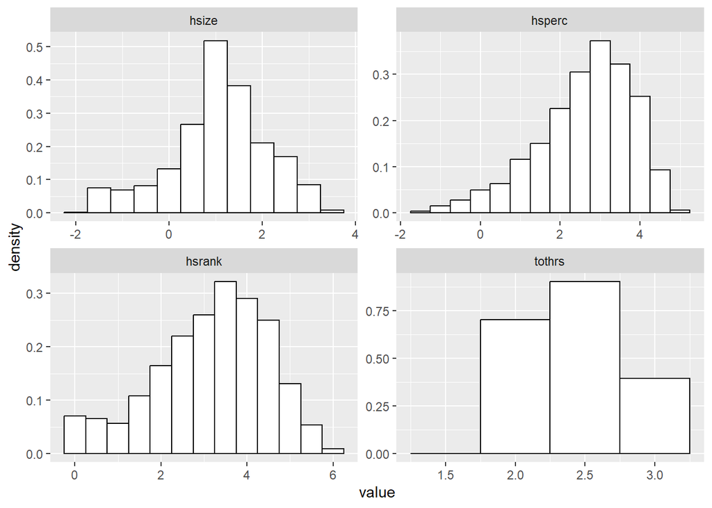

```r
data_transf = data[, (colnames(data) %in% c("hsperc", "hsrank", "hsize", "tothrs"))]

ggplot(gather(data_transf, cols, value), aes(x = value)) +
  geom_histogram(aes(y = after_stat(density)),
                 binwidth = 0.5,
                 colour = "black",
                 fill = "white") +
  facet_wrap(.~cols, ncol = 2, scales = 'free')
```

El siguiente paso es dividir el conjunto de datos en entrenamiento y test, para para entrenar y evaluar el modelo, en este caso se asigna un 70% para entrenamiento y 30% pata test.

```r
set.seed(123)
split <- createDataPartition(data$colgpa, p= .7, list = FALSE, times = 1)
train <- data[split,]
test <- data[-split,]
```

Con la función lm se crea modelo de regresión lineal multivariado.

```r
Model1 <- lm(colgpa ~., data=train)
summary(Model1)
```

```
##
## Call:
## lm(formula = colgpa ~ ., data = train)
##
## Residuals:
##      Min       1Q   Median       3Q      Max
## -2.17941 -0.35331  0.01654  0.36993  1.90546
##
## Coefficients:
##               Estimate Std. Error t value Pr(>|t|)
## (Intercept)  1.613e+00  1.549e-01  10.417  < 2e-16 ***
## sat          1.226e-03  8.352e-05  14.681  < 2e-16 ***
## tothrs       1.744e-01  3.002e-02   5.811 6.88e-09 ***
## athleteTRUE  1.314e-01  5.013e-02   2.621  0.00882 **
## verbmath    -1.377e-01  6.868e-02  -2.005  0.04502 *
## hsize       -1.608e-02  3.617e-02  -0.444  0.65677
## hsrank      -2.087e-02  4.194e-02  -0.498  0.61882
## hsperc      -1.972e-01  3.687e-02  -5.347 9.63e-08 ***
## femaleTRUE   1.494e-01  2.123e-02   7.034 2.49e-12 ***
## whiteTRUE    1.865e-02  7.552e-02   0.247  0.80495
## blackTRUE   -3.423e-01  8.674e-02  -3.946 8.13e-05 ***
## ---
## Signif. codes:  0 '***' 0.001 '**' 0.01 '*' 0.05 '.' 0.1 ' ' 1
##
## Residual standard error: 0.5372 on 2887 degrees of freedom
## Multiple R-squared:  0.3346, Adjusted R-squared:  0.3323
## F-statistic: 145.2 on 10 and 2887 DF,  p-value: < 2.2e-16
```

**Observaciones**

A continuación, se evalúa el desempeño del modelo en el conjunto de test.

```r
colgpa_pred1 <- predict(Model1, newdata=test, type='response')

RMSE(colgpa_pred1, test$colgpa)
```

```
## [1] 0.526387
```

```r
R2(colgpa_pred1, test$colgpa, form = "traditional")
```

```
## [1] 0.3664266
```

```r
MAE(colgpa_pred1, test$colgpa)
```

```
## [1] 0.4102672
```

Como se aprecia el valor de R2 mejora levemente, sin embargo sigue teniendo una baja capacidad predictiva.

A continuación, se eliminan las variables que menos aportaron información, y se precede a realizar el entrenamiento y test del modelo.

```r
train <- train[, !(colnames(train) %in% c("verbmath", "hsrank", "hsize", "white"))]
test <- test[, !(colnames(test) %in% c("verbmath", "hsrank", "hsizesq", "white"))]
```

```r
Model2 <- lm(colgpa ~., data=train)
summary(Model2)
```

```
##
## Call:
## lm(formula = colgpa ~ ., data = train)
##
## Residuals:
##      Min       1Q   Median       3Q      Max
## -2.18675 -0.35735  0.02004  0.37053  1.91287
##
## Coefficients:
##               Estimate Std. Error t value Pr(>|t|)
## (Intercept)  1.477e+00  1.279e-01  11.545  < 2e-16 ***
## sat          1.211e-03  8.286e-05  14.614  < 2e-16 ***
## tothrs       1.799e-01  3.003e-02   5.991 2.34e-09 ***
## athleteTRUE  1.300e-01  4.983e-02   2.609  0.00914 **
## hsperc      -2.141e-01  9.457e-03 -22.639  < 2e-16 ***
## femaleTRUE   1.423e-01  2.086e-02   6.823 1.08e-11 ***
## blackTRUE   -3.546e-01  4.675e-02  -7.585 4.44e-14 ***
## ---
## Signif. codes:  0 '***' 0.001 '**' 0.01 '*' 0.05 '.' 0.1 ' ' 1
##
## Residual standard error: 0.5383 on 2891 degrees of freedom
## Multiple R-squared:  0.3311, Adjusted R-squared:  0.3298
## F-statistic: 238.5 on 6 and 2891 DF,  p-value: < 2.2e-16
```

**Observaciones**

```r
colgpa_pred2 <- predict(Model2, newdata=test, type='response')

RMSE(colgpa_pred2, test$colgpa)
```

```
## [1] 0.5277911
```

```r
R2(colgpa_pred2, test$colgpa, form = "traditional")
```

```
## [1] 0.3630421
```

```r
MAE(colgpa_pred2, test$colgpa)
```

```
## [1] 0.4117143
```

### 5.2.2 **Modelo arboles de decisión y ensamble**

En este apartado se aborda un enfoque mas robusto para intentar dar respuesta a la pregunta. Para ello se usará como modelo base arboles de decisión y se usará una técnica de ensamble denominada baggging. En dicha técnica se generan múltiples modelos de árboles de decisión, a partir de la selección aleatoria con reemplazó de las features o variables independientes. Posteriormente se realiza un proceso de votación asignando el mismo peso a cada modelo generado y finalmente se toma el valor promedio de todos los modelos generados.

En primer lugar, se divide el conjunto de datos en entrenamiento y test, para evaluar la capacidad predictiva/generalización del modelo.

```r
set.seed(123)
split <- createDataPartition(data$colgpa, p= .7, list = FALSE, times = 1)
train <- data[split,]
test <- data[-split,]
```

Con el propósito de entrenar el modelo de forma robusta y disminuir la sobreoptimizacíon, se usa la técnica de validación cruzada; para este caso se selecciona el método k-fold, con una partición del conjunto de entrenamiento en 10 folds.

Para aplicar la técnica de bagging con arboles de decisión se usa la opción treebag.

```r
set.seed(123)

ctrl <- trainControl(method = "cv",  number = 10)

Model3 <- train(
  colgpa ~ .,
  data = train,
  method = "treebag",
  trControl = ctrl,
  importance = TRUE
  )

Model3
```

```
## Bagged CART
##
## 2898 samples
##   10 predictor
##
## No pre-processing
## Resampling: Cross-Validated (10 fold)
## Summary of sample sizes: 2608, 2608, 2608, 2607, 2608, 2609, ...
## Resampling results:
##
##   RMSE       Rsquared  MAE
##   0.5493791  0.304804  0.4366664
```

**Observaciones**

Los resultados muestran que el valor de R2 es de 0.304804, que es muy bajo y por ende se concluye que el modelo tiene baja capacidad predictiva.

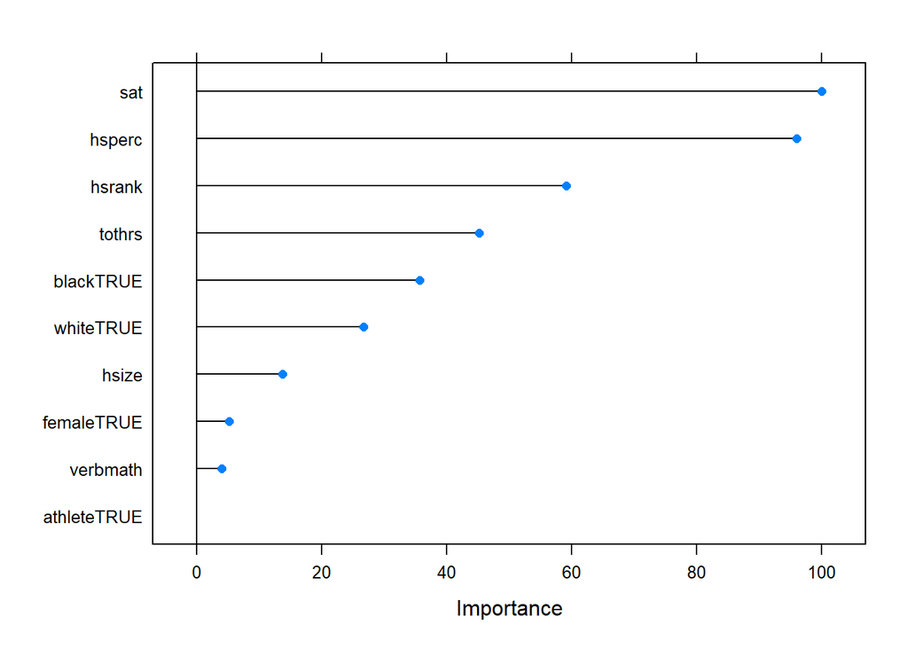

```r
plot(varImp(Model3), 10)
```

Finalmente se evalúa la capacidad predictiva/generalización del modelo en el conjunto de test. Tal como aprecia hay un leve mejora en el valor de R2, sin embargo el modelo tiene una capacidad predictiva baja.

```r
colgpa_pred3 <- predict(Model3, test)
postResample(colgpa_pred3, test$colgpa)
```

```
##      RMSE  Rsquared       MAE
## 0.5429094 0.3312981 0.4271228
```

# 6 **Exportar conjunto de datos final**

```r
write.csv(data, "data\\gpa_final.csv")
```